# Bank Selling Personal Loan Analysis

## Data Description:

The file Bank_Personal_Loan_Modelling.csv contains data on 5000 customers. The data include customer demographic information (age, income, etc.), the customer's relationship with the bank (mortgage, securities account, etc.), and the customer response to the last personal loan campaign (Personal Loan). Among these 5000 customers, only 480 (= 9.6%) accepted the personal loan that was offered to them in the earlier campaign.Domain:

## Banking Context:

This case is about a bank (Thera Bank)whose management wants to explore ways of converting its liability customers to personal loan customers (while retaining them as depositors). A campaign that the bank ran last year for liability customers showed a healthy conversion rate of over 9% success. This has encouraged the retail marketing department to devise campaigns with better target marketing to increase the success ratio with minimal budget.

## Attribute Information:

##### ID : Customer ID Age : Customer's age in completed years Experience: #years of professional experience Income : Annual income of the customer ZIP Code: Home Address ZIP code. Family: Family size of the customer CCAvg: Avg. spending on credit cards per month Education: Education Level. 1: Undergrad; 2: Graduate; 3: Advanced/Professional Mortgage: Value of house mortgage if any. Personal Loan: Did this customer accept the personal loan offered in the last campaign? Securities Account: Does the customer have a securities account with the bank? CD Account: Does the customer have a certificate of deposit (CD) account with the bank? Online: Does the customer use internet banking facilities? Credit card: Does the customer use a credit card issued by UniversalBank?

## Learning Outcomes :

- Exploratory Data Analysis
- Preparing the data to train a model
- Training and making predictions using a classification model
- Model evaluation

## Objective:

The classification goal is to predict the likelihood of a liability customer buying personal loans.

## Steps and tasks:

1. Read the column description and ensure you understand each attribute well
2. Study the data distribution in each attribute, share your findings (15 marks)
3. Get the target column distribution. Your comments (5 marks)
4. Split the data into training and test set in the ratio of 70:30 respectively (5 marks)
5. Use different classification models (Logistic, K-NN and Naïve Bayes) to predict
6. the likelihood of a customer buying personal loans (15 marks)
7. Print the confusion matrix for all the above models (5 marks)
8. Give your reasoning on which is the best model in this case and why it performs better? (5 marks)

### Import the necessary libraries

```python
#Importing important libraries
import warnings
warnings.filterwarnings('ignore')

import pandas as pd
import numpy as np
import seaborn as sns
import matplotlib.pyplot as plt

import scipy.stats as stats
from scipy.stats import zscore
from sklearn.model_selection import train_test_split
from sklearn import metrics
from sklearn.preprocessing import MinMaxScaler
from sklearn import preprocessing
from sklearn.metrics import classification_report

from sklearn.neighbors import KNeighborsClassifier
from sklearn.linear_model import LogisticRegression
from sklearn.naive_bayes import GaussianNB

from sklearn.model_selection import cross_val_score
from sklearn.metrics import roc_curve,accuracy_score,confusion_matrix,recall_score,precision_score,f1_score, auc
from sklearn import model_selection

from sklearn.model_selection import GridSearchCV
```

### Read the data as a data frame

```python
#Loading data in Pandas DataFrame
bank_data=pd.read_csv('/home/ratnesh/Downloads/Bank_Personal_Loan_Modelling.csv')

#Copy/Backup of DataFrame
bank_data1=bank_data.copy()

#Showing first 5 lines of DataFrame
bank_data.head()
```

|  | ID | Age | Experience | Income | ZIP Code | Family | CCAvg | Education | Mortgage | Personal Loan | Securities Account | CD Account | Online | CreditCard |
| --- | --- | --- | --- | --- | --- | --- | --- | --- | --- | --- | --- | --- | --- | --- |
| 0 | 1 | 25 | 1 | 49 | 91107 | 4 | 1.6 | 1 | 0 | 0 | 1 | 0 | 0 | 0 |
| 1 | 2 | 45 | 19 | 34 | 90089 | 3 | 1.5 | 1 | 0 | 0 | 1 | 0 | 0 | 0 |
| 2 | 3 | 39 | 15 | 11 | 94720 | 1 | 1.0 | 1 | 0 | 0 | 0 | 0 | 0 | 0 |
| 3 | 4 | 35 | 9 | 100 | 94112 | 1 | 2.7 | 2 | 0 | 0 | 0 | 0 | 0 | 0 |
| 4 | 5 | 35 | 8 | 45 | 91330 | 4 | 1.0 | 2 | 0 | 0 | 0 | 0 | 0 | 1 |

### Understanding Attributes and Data

```python
#Print the attributes' name

print('Attributes Names :- ',bank_data.columns.values,"\n")

#get the records information

print('Samples Details :-', bank_data.index,"\n")

print('Shape of Data :', bank_data.shape)
```

```
Attributes Names :-  ['ID' 'Age' 'Experience' 'Income' 'ZIP Code' 'Family' 'CCAvg' 'Education'
 'Mortgage' 'Personal Loan' 'Securities Account' 'CD Account' 'Online'
 'CreditCard']

Samples Details :- RangeIndex(start=0, stop=5000, step=1)

Shape of Data : (5000, 14)
```

### Basic EDA

```python
#Get the Data Types of attributes
bank_data.dtypes
```

```
ID                      int64
Age                     int64
Experience              int64
Income                  int64
ZIP Code                int64
Family                  int64
CCAvg                 float64
Education               int64
Mortgage                int64
Personal Loan           int64
Securities Account      int64
CD Account              int64
Online                  int64
CreditCard              int64
dtype: object
```

```python
#to get the complete information of attributes (like how many not null values in that attribute, datatype of attribute etc)
bank_data.info()
```

```
<class 'pandas.core.frame.DataFrame'>
RangeIndex: 5000 entries, 0 to 4999
Data columns (total 14 columns):
ID                    5000 non-null int64
Age                   5000 non-null int64
Experience            5000 non-null int64
Income                5000 non-null int64
ZIP Code              5000 non-null int64
Family                5000 non-null int64
CCAvg                 5000 non-null float64
Education             5000 non-null int64
Mortgage              5000 non-null int64
Personal Loan         5000 non-null int64
Securities Account    5000 non-null int64
CD Account            5000 non-null int64
Online                5000 non-null int64
CreditCard            5000 non-null int64
dtypes: float64(1), int64(13)
memory usage: 547.0 KB
```

```python
# Change the Data Type of "ZIP Code" and "Personal Loan"

for col in ['ZIP Code']:
    bank_data[col] = bank_data[col].astype('object')
```

```python
#Get the Data Types of attributes
bank_data.dtypes
```

```
ID                      int64
Age                     int64
Experience              int64
Income                  int64
ZIP Code               object
Family                  int64
CCAvg                 float64
Education               int64
Mortgage                int64
Personal Loan           int64
Securities Account      int64
CD Account              int64
Online                  int64
CreditCard              int64
dtype: object
```

### Checking the presence of missing values

```python
# checking for any missing values
#bank_data.isna().sum()
bank_data.apply(lambda x : sum(x.isnull()))
```

```
ID                    0
Age                   0
Experience            0
Income                0
ZIP Code              0
Family                0
CCAvg                 0
Education             0
Mortgage              0
Personal Loan         0
Securities Account    0
CD Account            0
Online                0
CreditCard            0
dtype: int64
```

```python
#checking not null values in each attributes
bank_data.notnull().sum()
```

```
ID                    5000
Age                   5000
Experience            5000
Income                5000
ZIP Code              5000
Family                5000
CCAvg                 5000
Education             5000
Mortgage              5000
Personal Loan         5000
Securities Account    5000
CD Account            5000
Online                5000
CreditCard            5000
dtype: int64
```

#### As per above result there is no Missing value in any Attributes

```python
#distinct values count in each Attributes
bank_data.apply(lambda x: len(x.unique()))
```

```
ID                    5000
Age                     45
Experience              47
Income                 162
ZIP Code               467
Family                   4
CCAvg                  108
Education                3
Mortgage               347
Personal Loan            2
Securities Account       2
CD Account               2
Online                   2
CreditCard               2
dtype: int64
```

### 5 Points Summary

```python
# five point summary of contineous attributes
bank_data.describe()
```

|  | ID | Age | Experience | Income | Family | CCAvg | Education | Mortgage | Personal Loan | Securities Account | CD Account | Online | CreditCard |
| --- | --- | --- | --- | --- | --- | --- | --- | --- | --- | --- | --- | --- | --- |
| count | 5000.000000 | 5000.000000 | 5000.000000 | 5000.000000 | 5000.000000 | 5000.000000 | 5000.000000 | 5000.000000 | 5000.000000 | 5000.000000 | 5000.00000 | 5000.000000 | 5000.000000 |
| mean | 2500.500000 | 45.338400 | 20.104600 | 73.774200 | 2.396400 | 1.937938 | 1.881000 | 56.498800 | 0.096000 | 0.104400 | 0.06040 | 0.596800 | 0.294000 |
| std | 1443.520003 | 11.463166 | 11.467954 | 46.033729 | 1.147663 | 1.747659 | 0.839869 | 101.713802 | 0.294621 | 0.305809 | 0.23825 | 0.490589 | 0.455637 |
| min | 1.000000 | 23.000000 | -3.000000 | 8.000000 | 1.000000 | 0.000000 | 1.000000 | 0.000000 | 0.000000 | 0.000000 | 0.00000 | 0.000000 | 0.000000 |
| 25% | 1250.750000 | 35.000000 | 10.000000 | 39.000000 | 1.000000 | 0.700000 | 1.000000 | 0.000000 | 0.000000 | 0.000000 | 0.00000 | 0.000000 | 0.000000 |
| 50% | 2500.500000 | 45.000000 | 20.000000 | 64.000000 | 2.000000 | 1.500000 | 2.000000 | 0.000000 | 0.000000 | 0.000000 | 0.00000 | 1.000000 | 0.000000 |
| 75% | 3750.250000 | 55.000000 | 30.000000 | 98.000000 | 3.000000 | 2.500000 | 3.000000 | 101.000000 | 0.000000 | 0.000000 | 0.00000 | 1.000000 | 1.000000 |
| max | 5000.000000 | 67.000000 | 43.000000 | 224.000000 | 4.000000 | 10.000000 | 3.000000 | 635.000000 | 1.000000 | 1.000000 | 1.00000 | 1.000000 | 1.000000 |

```python
# five point summary of contineous attributes
bank_data.describe().T
```

|  | count | mean | std | min | 25% | 50% | 75% | max |
| --- | --- | --- | --- | --- | --- | --- | --- | --- |
| ID | 5000.0 | 2500.500000 | 1443.520003 | 1.0 | 1250.75 | 2500.5 | 3750.25 | 5000.0 |
| Age | 5000.0 | 45.338400 | 11.463166 | 23.0 | 35.00 | 45.0 | 55.00 | 67.0 |
| Experience | 5000.0 | 20.104600 | 11.467954 | -3.0 | 10.00 | 20.0 | 30.00 | 43.0 |
| Income | 5000.0 | 73.774200 | 46.033729 | 8.0 | 39.00 | 64.0 | 98.00 | 224.0 |
| Family | 5000.0 | 2.396400 | 1.147663 | 1.0 | 1.00 | 2.0 | 3.00 | 4.0 |
| CCAvg | 5000.0 | 1.937938 | 1.747659 | 0.0 | 0.70 | 1.5 | 2.50 | 10.0 |
| Education | 5000.0 | 1.881000 | 0.839869 | 1.0 | 1.00 | 2.0 | 3.00 | 3.0 |
| Mortgage | 5000.0 | 56.498800 | 101.713802 | 0.0 | 0.00 | 0.0 | 101.00 | 635.0 |
| Personal Loan | 5000.0 | 0.096000 | 0.294621 | 0.0 | 0.00 | 0.0 | 0.00 | 1.0 |
| Securities Account | 5000.0 | 0.104400 | 0.305809 | 0.0 | 0.00 | 0.0 | 0.00 | 1.0 |
| CD Account | 5000.0 | 0.060400 | 0.238250 | 0.0 | 0.00 | 0.0 | 0.00 | 1.0 |
| Online | 5000.0 | 0.596800 | 0.490589 | 0.0 | 0.00 | 1.0 | 1.00 | 1.0 |
| CreditCard | 5000.0 | 0.294000 | 0.455637 | 0.0 | 0.00 | 0.0 | 1.00 | 1.0 |

## Univariate analysis

```python
index = 'ID';
target = 'Personal Loan'
non_features = [index,target]

num_features = [col for col in bank_data.select_dtypes(np.number).columns if col not in non_features]
cat_features = [col for col in bank_data.select_dtypes('object').columns if col not in non_features]


#bank_data[target] = bank_data[target].map({1:'Yes',0:'No'})
#bank_data['Education_cat']=bank_data['Education'].map({1: 'Undergrad', 2: 'Graduate', 3: 'Advanced/Professional'})
```

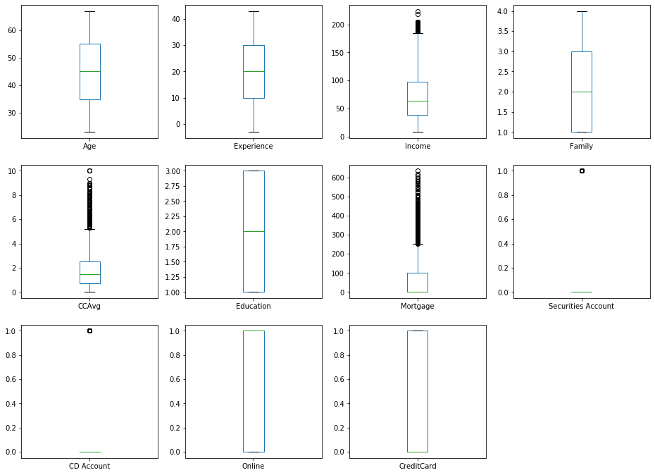

```python
bank_data[num_features].plot(kind='box',subplots=True, layout=(4,4), fontsize=10, figsize=(16,16));
```

### Clearing Outlier with upper quartile value and lower quartile value

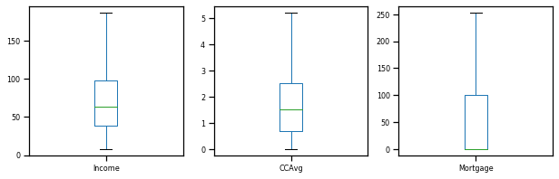

```python
skewed = ['Family'];
withOutliers = ['Income', 'CCAvg', 'Mortgage']

IQR=bank_data[withOutliers].describe().T['75%']-bank_data[withOutliers].describe().T['25%']

LW,UW = bank_data[withOutliers].describe().T['25%']-(IQR*1.5),bank_data[withOutliers].describe().T['75%']+(IQR*1.5)


for i in withOutliers:
    bank_data[i][bank_data[i]>UW[i]]=UW[i];
    bank_data[i][bank_data[i]<LW[i]]=LW[i]
bank_data[withOutliers].plot(kind='box',subplots=True, layout=(4,4), fontsize=8, figsize=(14,14));
```

### Skewness of Attributes

```python
#Skewness table for categorical attributes
skewness = pd.DataFrame({'Skewness' : [stats.skew(bank_data.Age)
                                       ,stats.skew(bank_data.Experience)
                                       ,stats.skew(bank_data.Income)
                                       ,stats.skew(bank_data.Family)
                                       ,stats.skew(bank_data.CCAvg)
                                       ,stats.skew(bank_data.Education)
                                       ,stats.skew(bank_data.Mortgage)
                                       ,stats.skew(bank_data['Securities Account'])
                                       ,stats.skew(bank_data['CD Account'])
                                       ,stats.skew(bank_data.Online)
                                       ,stats.skew(bank_data.CreditCard)]},
index=['Age','Experience','Income','Family','CCAvg','Education','Mortgage',
                    'Securities Account','CD Account','Online','CreditCard'])
skewness
```

|  | Skewness |
| --- | --- |
| Age | -0.029332 |
| Experience | -0.026317 |
| Income | 0.803766 |
| Family | 0.155174 |
| CCAvg | 0.925214 |
| Education | 0.227025 |
| Mortgage | 1.348895 |
| Securities Account | 2.587492 |
| CD Account | 3.690606 |
| Online | -0.394667 |
| CreditCard | 0.904318 |

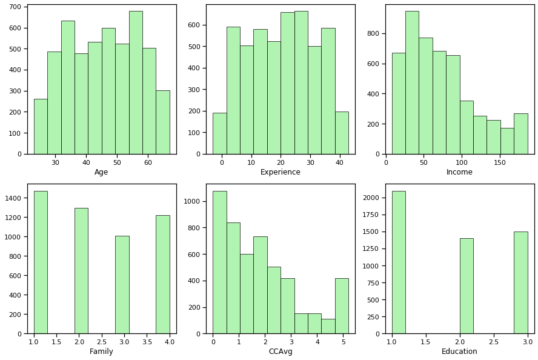

```python
plt.figure(figsize= (15,10))
plt.subplot(231)
plt.hist(bank_data.Age, color='lightgreen', edgecolor = 'black', alpha = 0.7)
plt.xlabel('Age')

plt.subplot(232)
plt.hist(bank_data.Experience, color='lightgreen', edgecolor = 'black', alpha = 0.7)
plt.xlabel('Experience')

plt.subplot(233)
plt.hist(bank_data.Income, color='lightgreen', edgecolor = 'black', alpha = 0.7)
plt.xlabel('Income')

plt.subplot(234)
plt.hist(bank_data.Family, color='lightgreen', edgecolor = 'black', alpha = 0.7)
plt.xlabel('Family')

plt.subplot(235)
plt.hist(bank_data.CCAvg, color='lightgreen', edgecolor = 'black', alpha = 0.7)
plt.xlabel('CCAvg')

plt.subplot(236)
plt.hist(bank_data.Education, color='lightgreen', edgecolor = 'black', alpha = 0.7)
plt.xlabel('Education')

plt.show()
```

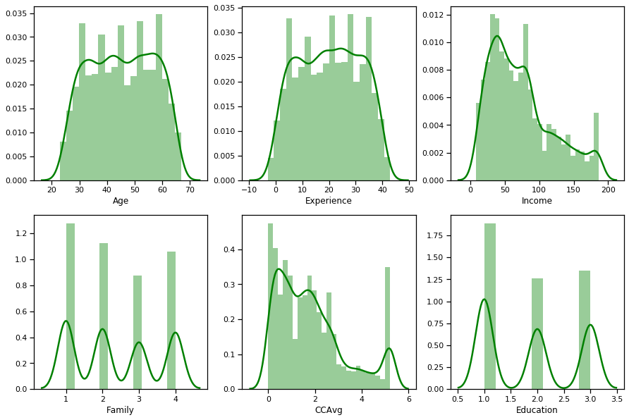

```python
plt.figure(figsize= (15,10))
plt.subplot(231)
sns.distplot(bank_data.Age, color='green')
plt.xlabel('Age')

plt.subplot(232)
sns.distplot(bank_data.Experience, color='green')
plt.xlabel('Experience')

plt.subplot(233)
sns.distplot(bank_data.Income, color='green')
plt.xlabel('Income')

plt.subplot(234)
sns.distplot(bank_data.Family, color='green')
plt.xlabel('Family')

plt.subplot(235)
sns.distplot(bank_data.CCAvg, color='green')
plt.xlabel('CCAvg')

plt.subplot(236)
sns.distplot(bank_data.Education, color='green')
plt.xlabel('Education')

plt.show()
```

### Observation :

- Age & Experience seems to be quiet normally distributed
- Income & CC Average are highly skewed

### Treating minus values in Experience

```python
# Negative Experience sample count
print("Total Records having negative Experience :\t",bank_data[bank_data['Experience'] < 0]['Experience'].count())

#check the amount of negative values
bank_data[bank_data['Experience'] < 0]['Experience'].value_counts()
```

```
Total Records having negative Experience :	 52
```

```
-1    33
-2    15
-3     4
Name: Experience, dtype: int64
```

```python
#Negative Experience distributed over Age
bank_data[bank_data['Experience'] < 0]['Age'].value_counts()
```

```
25    18
24    17
23    12
29     3
28     1
26     1
Name: Age, dtype: int64
```

```python
# Get a list of 'Age' values where we found some negative values in 'Experience'
ages = bank_data[bank_data['Experience'] < 0]['Age'].unique().tolist()
ages
```

```
[25, 24, 28, 23, 29, 26]
```

```python
indexes = bank_data[bank_data['Experience'] < 0].index.tolist()
```

```python
for i in indexes:
    for x in ages:
        bank_data.loc[i,'Experience'] = bank_data[(bank_data.Age == x) & (bank_data.Experience > 0)].Experience.mean()
```

```python
bank_data[bank_data['Experience'] < 0]['Age'].value_counts()
```

```
Series([], Name: Age, dtype: int64)
```

```python
bank_data.Experience.describe()
```

```
count    5000.000000
mean       20.135743
std        11.413140
min         0.000000
25%        10.000000
50%        20.000000
75%        30.000000
max        43.000000
Name: Experience, dtype: float64
```

### Bivariate Analysis

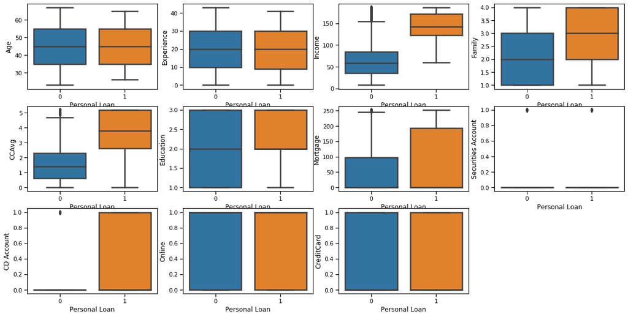

```python
plt.figure(figsize=(20,10))
for i,col in enumerate(num_features,start=1):
    plt.subplot(3,4,i);
    sns.boxplot(y=bank_data[col],x=bank_data[target]);
plt.show()
```

### Observation:

#### income, family, CCAvg, Education filds show some siginificant influence on target

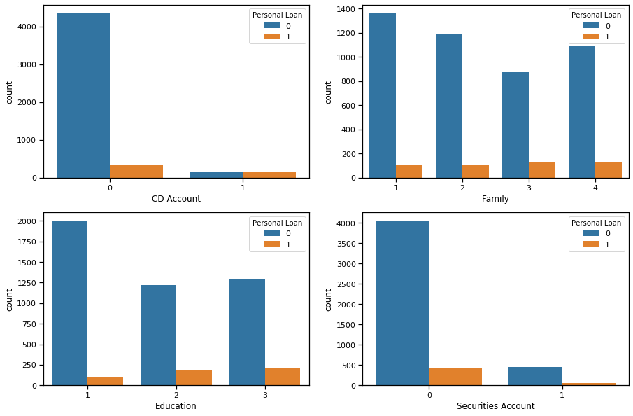

```python
plt.figure(figsize= (15,10))
plt.subplot(221)
sns.countplot(x='CD Account', data=bank_data,  hue='Personal Loan')

plt.subplot(222)
sns.countplot(x='Family',    data=bank_data,   hue='Personal Loan')

plt.subplot(223)
sns.countplot(x="Education", data=bank_data,   hue="Personal Loan")

plt.subplot(224)
sns.countplot(x="Securities Account", data=bank_data,hue="Personal Loan")


plt.show()
```

### Observation :

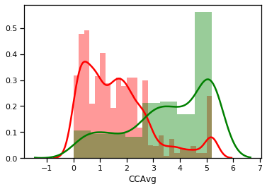

```python
sns.distplot( bank_data[bank_data['Personal Loan'] == 0]['CCAvg'], color = 'r')
sns.distplot( bank_data[bank_data['Personal Loan'] == 1]['CCAvg'], color = 'g')
plt.show()
```

```python
print('Credit card spending of Non-Loan customers:=\t', bank_data[bank_data['Personal Loan'] == 0]['CCAvg'].median()*1000)
print('Credit card spending of Loan customers    :=\t', bank_data[bank_data['Personal Loan'] == 1]['CCAvg'].median()*1000)
```

```
Credit card spending of Non-Loan customers:=	 1400.0
Credit card spending of Loan customers    :=	 3800.0
```

### correlation in Attributes

```python
#Corelation between Attributes
bank_data[['Personal Loan', 'Age', 'Income', 'CCAvg', 'Mortgage']].corr()
```

|  | Personal Loan | Age | Income | CCAvg | Mortgage |
| --- | --- | --- | --- | --- | --- |
| Personal Loan | 1.000000 | -0.007726 | 0.504559 | 0.383306 | 0.092989 |
| Age | -0.007726 | 1.000000 | -0.054988 | -0.052032 | -0.012033 |
| Income | 0.504559 | -0.054988 | 1.000000 | 0.637869 | 0.135018 |
| CCAvg | 0.383306 | -0.052032 | 0.637869 | 1.000000 | 0.068329 |
| Mortgage | 0.092989 | -0.012033 | 0.135018 | 0.068329 | 1.000000 |

#### Observation:

#### The graph show persons who have personal loan have a higher credit card average. Average credit card spending with a median of 3800 dollar indicates a higher probability of personal loan. Lower credit card spending with a median of 1400 dollars is less likely to take a loan.

```python
# dropping ZIP Code
df =bank_data.drop(['ZIP Code'], axis=1, inplace=True)
```

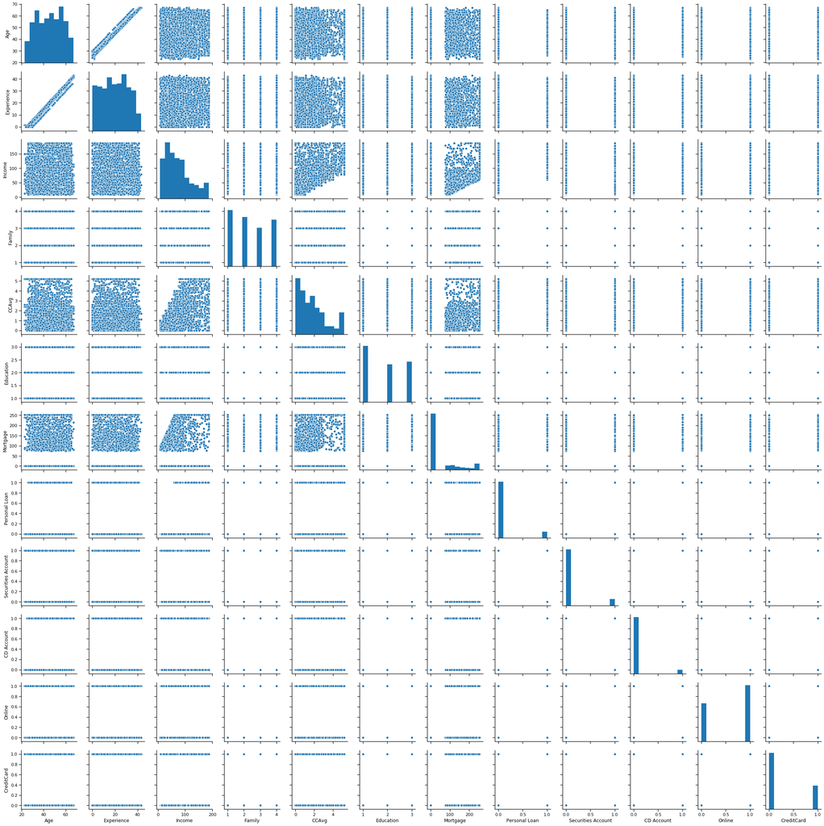

```python
sns.pairplot(bank_data.iloc[:,1:])
#sns.pairplot(bank_data.iloc[:,1:])
plt.show()
```

#### CCAvg is also a positively skewed variable and average spending is between 0K to 10K and majority spends less than 2.5K.

#### The variables family and education are ordinal variables. The distribution of families is evenly distributed

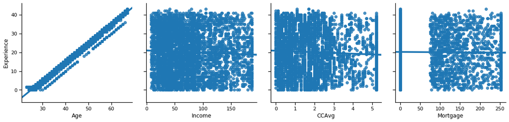

```python
ncol = ['Age', 'Income','CCAvg', 'Mortgage']
grid = sns.PairGrid(bank_data, y_vars = 'Experience', x_vars = ncol, height = 4)
grid.map(sns.regplot)
plt.show()
```

### Multivariate analysis

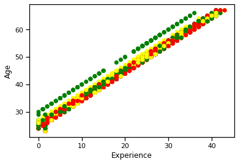

```python
fig, ax = plt.subplots()
colors = {1:'red',2:'yellow',3:'green'}
ax.scatter(bank_data['Experience'],bank_data['Age'],c=bank_data['Education'].apply(lambda x:colors[x]))
plt.xlabel('Experience')
plt.ylabel('Age')
```

### Observation:

#### The above plot show with experience and age have a positive correlation. As experience increase age also increases. Also the colors show the education level. There is gap in the mid forties of age and also more people in the under graduate level

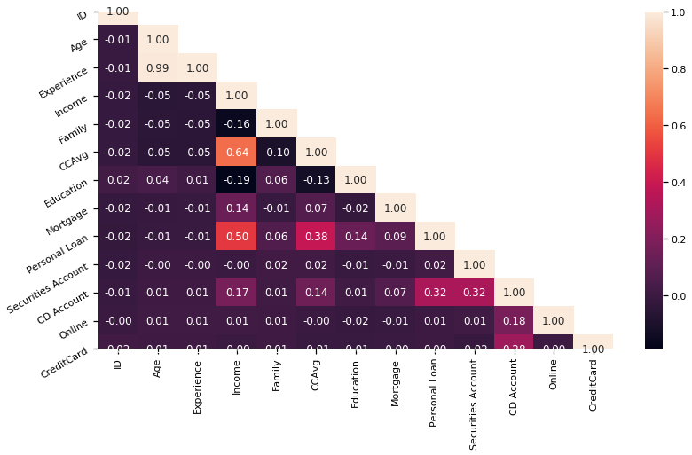

```python
# Correlation with heat map

corr = bank_data.corr()
sns.set_context("notebook", font_scale=1.0, rc={"lines.linewidth": 2.5})
plt.figure(figsize=(13,7))

# create a mask so we only see the correlation values once
mask = np.zeros_like(corr)
mask[np.triu_indices_from(mask, 1)] = True

a = sns.heatmap(corr,mask=mask, annot=True, fmt='.2f')

rotx = a.set_xticklabels(a.get_xticklabels(), rotation=90)
roty = a.set_yticklabels(a.get_yticklabels(), rotation=30)
```

### Observation :-

- Income and CCAvg is moderately correlated.
- Age and Experience is highly correlated.

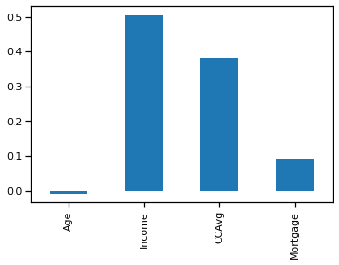

```python
bank_data[['Personal Loan', 'Age', 'Income', 'CCAvg', 'Mortgage']].corr()['Personal Loan'][1:].plot.bar()
```

### Observation

The above diagram shows a clear vision on the correlation between the independant variable and dependant variables, we see that 'Income' and 'Credit Card Average' has some correlation with 'Personal Loan'.

### Target and independent variable attribute sets

```python
X = bank_data.drop(["ID", "Personal Loan"] , axis = 1)
y = bank_data[target]
X.head()
```

|  | Age | Experience | Income | Family | CCAvg | Education | Mortgage | Securities Account | CD Account | Online | CreditCard |
| --- | --- | --- | --- | --- | --- | --- | --- | --- | --- | --- | --- |
| 0 | 25 | 1.0 | 49.0 | 4 | 1.6 | 1 | 0.0 | 1 | 0 | 0 | 0 |
| 1 | 45 | 19.0 | 34.0 | 3 | 1.5 | 1 | 0.0 | 1 | 0 | 0 | 0 |
| 2 | 39 | 15.0 | 11.0 | 1 | 1.0 | 1 | 0.0 | 0 | 0 | 0 | 0 |
| 3 | 35 | 9.0 | 100.0 | 1 | 2.7 | 2 | 0.0 | 0 | 0 | 0 | 0 |
| 4 | 35 | 8.0 | 45.0 | 4 | 1.0 | 2 | 0.0 | 0 | 0 | 0 | 1 |

```python
X = X.apply(zscore)
```

### Spliting Data into Traing set and Test set

```python
X_train, X_test, y_train, y_test=train_test_split(X, y, test_size=0.3, random_state=1)


# print the shapes of the new X objects
print(X_train.shape)
print(X_test.shape)
```

```
(3500, 11)
(1500, 11)
```

### Logistic Regression

```python
model = LogisticRegression()
model.fit(X_train, y_train)
```

```
LogisticRegression(C=1.0, class_weight=None, dual=False, fit_intercept=True,
                   intercept_scaling=1, l1_ratio=None, max_iter=100,
                   multi_class='warn', n_jobs=None, penalty='l2',
                   random_state=None, solver='warn', tol=0.0001, verbose=0,
                   warm_start=False)
```

### Logistic Regression Model Score

```python
y_predict = model.predict(X_test)

# Accuracy of Training data set
print("Score for Train Data =\t", model.score(X_train, y_train))


# Accuracy of Testing data set
print("Score for Test Data =\t",model.score(X_test, y_test))
```

```
Score for Train Data =	 0.9565714285714285
Score for Test Data =	 0.9486666666666667
```

### Confusion Matrix

```python
metrics.confusion_matrix(y_predict, y_test)
```

```
array([[1335,   61],
       [  16,   88]])
```

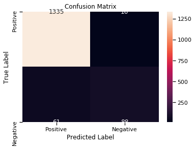

```python
# Confusion Matrix
cm = confusion_matrix(y_test, y_predict)

class_label = ["Positive", "Negative"]
df_cm = pd.DataFrame(cm, index = class_label, columns = class_label)
sns.heatmap(df_cm, annot = True, fmt = "d")
plt.title("Confusion Matrix")
plt.xlabel("Predicted Label")
plt.ylabel("True Label")
plt.show()
```

### Classification Report

```python
# Classification Report
print(classification_report(y_test, y_predict))
```

```
              precision    recall  f1-score   support

           0       0.96      0.99      0.97      1351
           1       0.85      0.59      0.70       149

    accuracy                           0.95      1500
   macro avg       0.90      0.79      0.83      1500
weighted avg       0.95      0.95      0.94      1500
```

```python
model.predict_proba(X_train)
```

```
array([[9.99855554e-01, 1.44446366e-04],
       [9.99424588e-01, 5.75412140e-04],
       [9.90150360e-01, 9.84964047e-03],
       ...,
       [9.99983439e-01, 1.65612096e-05],
       [9.48341348e-01, 5.16586515e-02],
       [8.96685790e-01, 1.03314210e-01]])
```

### fpr and tpr and thresholds

```python
y_predictProb = model.predict_proba(X_train)

fpr, tpr, thresholds = roc_curve(y_train, y_predictProb[::,1])

roc_auc = auc(fpr, tpr)

print("auc :-",roc_auc)
```

```
auc :- 0.9661896449650551
```

### Accuracy, Precision, Recall value & F1 Score

```python
optimalF1 = 0
optimalTh = 0

for th in thresholds:
    preds = np.where(model.predict_proba(X_test)[:,1] > th, 1, 0)
    f1Score = f1_score(y_test, preds)
    if(optimalF1 < f1Score):
        optimalF1 = f1Score
        optimalTh = th

THRESHOLD = optimalTh
preds = np.where(model.predict_proba(X_test)[:,1] > THRESHOLD, 1, 0)
pd.DataFrame(data=[accuracy_score(y_test, preds),
                   recall_score(y_test, preds),
                   precision_score(y_test, preds),
                   f1_score(y_test, preds)],
             index=["accuracy", "recall", "precision", "f1Score"])
```

|  | 0 |
| --- | --- |
| accuracy | 0.951333 |
| recall | 0.617450 |
| precision | 0.851852 |
| f1Score | 0.715953 |

#### AUC Curve

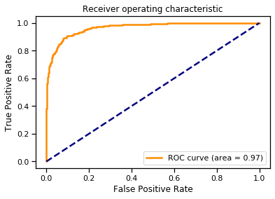

```python
plt.plot(fpr, tpr, color='darkorange', label='ROC curve (area = %0.2f)' % roc_auc)
plt.plot([0, 1], [0, 1], color='navy', linestyle='--')
plt.xlabel('False Positive Rate')
plt.ylabel('True Positive Rate')
plt.title('Receiver operating characteristic')
plt.legend(loc="lower right")
```

#### K-Nearest Neighbour Classifier

```python
KNNH=KNeighborsClassifier()
KNNH.fit(X_train, y_train)
```

```
KNeighborsClassifier(algorithm='auto', leaf_size=30, metric='minkowski',
                     metric_params=None, n_jobs=None, n_neighbors=5, p=2,
                     weights='uniform')
```

#### K-Nearest Neighbour Classifier Model Score

```python
# For every test data point, predict it's label based on 5 nearest neighbours in this model. The majority class will
# be assigned to the test data point
predicted_labels = KNNH.predict(X_train)


## Accuracy of Train data set
print("Score for Train Data =\t", KNNH.score(X_train, y_train))


## Accuracy of Test data set
print("Score for Test Data =\t", KNNH.score(X_test, y_test))
```

```
Score for Train Data =	 0.9711428571428572
Score for Test Data =	 0.952
```

```python
# 10-fold (cv=10) cross-validation with K=5 (n_neighbors=5) for KNN (the n_neighbors parameter)

# instantiate model
knn = KNeighborsClassifier(n_neighbors=5)

# store scores in scores object
# scoring metric used here is 'accuracy' because it's a classification problem
# cross_val_score takes care of splitting X and y into the 10 folds that's why we pass X and y entirely instead of X_train and y_train
scores = cross_val_score(knn, X, y, cv=10, scoring='accuracy')
print(scores)
```

```
[0.962 0.968 0.962 0.972 0.956 0.974 0.952 0.95  0.958 0.956]
```

```python
# use average accuracy as an estimate of out-of-sample accuracy

# scores is a numpy array so we can use the mean method
print(scores.mean())
```

```
0.961
```

#### Optimal value of K for KNN

```python
# search for an optimal value of K for KNN

#Max value of K
maxK = int(np.sqrt(X_train.shape[0]))

# list of integer for K value
k_range = range(1, maxK+1)

# list of scores from k_range
k_scores = []

# 1. we will loop through reasonable values of k
for k in k_range:
    # 2. run KNeighborsClassifier with k neighbours
    knn = KNeighborsClassifier(n_neighbors=k)
    # 3. obtain cross_val_score for KNeighborsClassifier with k neighbours
    scores = cross_val_score(knn, X, y, cv=10, scoring='accuracy')
    # 4. append mean of scores for k neighbors to k_scores list
    k_scores.append(scores.mean())
print(k_scores)

# changing to misclassification error
misError = [1 - x for x in k_scores]

optimal_k = neighbors[misError.index(min(misError))]
print("The value of optimal K is = ",optimal_k)
```

[output not shown]

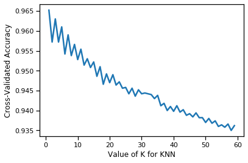

```python
# plot the value of K for KNN (x-axis) versus the cross-validated accuracy (y-axis)
plt.plot(k_range, k_scores)
plt.xlabel('Value of K for KNN')
plt.ylabel('Cross-Validated Accuracy')
```

#### Rebuild the KNN using the optimum value

```python
NNH = KNeighborsClassifier(n_neighbors=optimal_k)
NNH.fit(X_train, y_train)


## Train Accuracy
print("Score for training data is =\t", NNH.score(X_train, y_train))
## Test accuracy
print("Score for test data is =\t", NNH.score(X_test, y_test))
```

```
Score for training data is =	 1.0
Score for test data is =	 0.954
```

### Confusion Matrix

```python
# Confusion matrix
knn_cm=metrics.confusion_matrix(y_test, NNH.predict(X_test))
knn_cm
```

```
array([[1333,   18],
       [  51,   98]])
```

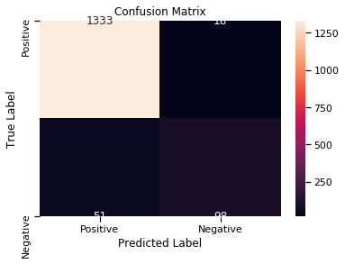

```python
# Confusion Matrix
knn_cm=metrics.confusion_matrix(y_test, NNH.predict(X_test))

class_label = ["Positive", "Negative"]
df_cm = pd.DataFrame(knn_cm, index = class_label, columns = class_label)
sns.heatmap(df_cm, annot = True, fmt = "d")
plt.title("Confusion Matrix")
plt.xlabel("Predicted Label")
plt.ylabel("True Label")
plt.show()
```

### Classification Report

```python
# Classification Report
print(classification_report(y_test, y_predict))
```

```
              precision    recall  f1-score   support

           0       0.96      0.99      0.97      1351
           1       0.85      0.59      0.70       149

    accuracy                           0.95      1500
   macro avg       0.90      0.79      0.83      1500
weighted avg       0.95      0.95      0.94      1500
```

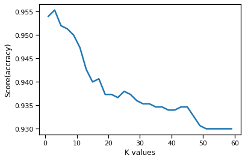

```python
#find avaible value of k
score_list=[]
k_value=[]
for i in myList:
    knn_available=KNeighborsClassifier(n_neighbors=i)
    knn_available.fit(X_train,y_train.values.ravel())

    score_list.append(knn_available.score(X_test,y_test))
    k_value.append(i)
plt.plot(myList,score_list)
plt.xlabel("K values")
plt.ylabel("Score(accracy)")
plt.show()
```

#### fpr and tpr and thresholds

```python
y_predictProb = KNNH.predict_proba(X_test)
fpr, tpr, thresholds = roc_curve(y_test, y_predictProb[::,1])
roc_auc = auc(fpr, tpr)
print("auc :-",roc_auc)
```

```
auc :- 0.9136955474195102
```

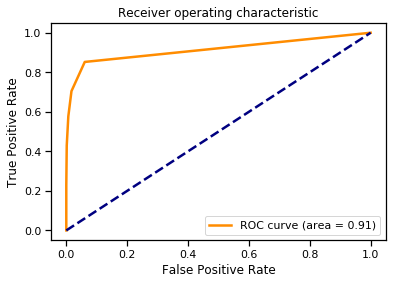

```python
plt.plot(fpr, tpr, color='darkorange', label='ROC curve (area = %0.2f)' % roc_auc)
plt.plot([0, 1], [0, 1], color='navy', linestyle='--')
plt.xlabel('False Positive Rate')
plt.ylabel('True Positive Rate')
plt.title('Receiver operating characteristic')
plt.legend(loc="lower right")
```

#### Accuracy, Precision, Recall value & F1 Score

```python
optimalF1 = 0
optimalTh = 0
for th in thresholds:
    preds = np.where(KNNH.predict_proba(X_test)[:,1] > th, 1, 0)
    f1Score = f1_score(y_test, preds)
    if(optimalF1 < f1Score):
        optimalF1 = f1Score
        optimalTh = th

THRESHOLD = optimalTh
preds = np.where(KNNH.predict_proba(X_test)[:,1] > THRESHOLD, 1, 0)
pd.DataFrame(data=[accuracy_score(y_test, preds),
                   recall_score(y_test, preds),
                   precision_score(y_test, preds),
                   f1_score(y_test, preds)],
             index=["accuracy", "recall", "precision", "f1Score"])
```

|  | 0 |
| --- | --- |
| accuracy | 0.955333 |
| recall | 0.704698 |
| precision | 0.820312 |
| f1Score | 0.758123 |

#### Efficient parameter tuning using GridSearchCV

```python
# create a parameter grid: map the parameter names to the values that should be searched
# simply a python dictionary
# key: parameter name
# value: list of values that should be searched for that parameter
# single key-value pair for param_grid
param_grid = dict(n_neighbors=k_range)
print(param_grid)
```

```
{'n_neighbors': range(1, 60)}
```

```python
# instantiate the grid
grid = GridSearchCV(knn, param_grid, cv=10, scoring='accuracy')
```

```python
# fit the grid with data
grid.fit(X, y)
```

```
GridSearchCV(cv=10, error_score='raise-deprecating',
             estimator=KNeighborsClassifier(algorithm='auto', leaf_size=30,
                                            metric='minkowski',
                                            metric_params=None, n_jobs=None,
                                            n_neighbors=59, p=2,
                                            weights='uniform'),
             iid='warn', n_jobs=None, param_grid={'n_neighbors': range(1, 60)},
             pre_dispatch='2*n_jobs', refit=True, return_train_score=False,
             scoring='accuracy', verbose=0)
```

```python
# view the complete results (list of named tuples)
grid.cv_results_
```

[output not shown]

#### Naive Bayes Classifier

```python
model_naive = GaussianNB()
model_naive.fit(X_train, y_train)

# make predictions
predicted = model_naive.predict(X_test)
```

#### Naive Bayes Model Score

```python
print("Score for train data =\t", model_naive.score(X_train, y_train))
print("Score for test data =\t", model_naive.score(X_test, y_test))
```

```
Score for train data =	 0.9005714285714286
Score for test data =	 0.8906666666666667
```

#### Confusion Matrix

```python
nb_cm=metrics.confusion_matrix(predicted, y_test)
nb_cm
```

```
array([[1247,   60],
       [ 104,   89]])
```

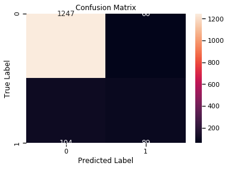

```python
# Confusion Matrix
nb_cm=metrics.confusion_matrix(predicted, y_test)

class_label = ["Positive", "Negative"]
df_cm = pd.DataFrame(cm, index = class_label, columns = class_label)
sns.heatmap(nb_cm, annot = True, fmt = "d")
plt.title("Confusion Matrix")
plt.xlabel("Predicted Label")
plt.ylabel("True Label")
plt.show()
```

```python
# Classification Report
print(classification_report(predicted, y_test))
```

```
              precision    recall  f1-score   support

           0       0.92      0.95      0.94      1307
           1       0.60      0.46      0.52       193

    accuracy                           0.89      1500
   macro avg       0.76      0.71      0.73      1500
weighted avg       0.88      0.89      0.88      1500
```

### fpr and tpr and thresholds

```python
y_predictProb = model_naive.predict_proba(X_test)

fpr, tpr, thresholds = roc_curve(y_test, y_predictProb[::,1])
roc_auc = auc(fpr, tpr)
print("auc :-",roc_auc)
```

```
auc :- 0.9230845657454831
```

### AUC Curve

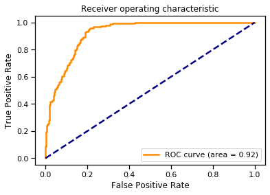

```python
plt.plot(fpr, tpr, color='darkorange', label='ROC curve (area = %0.2f)' % roc_auc)
plt.plot([0, 1], [0, 1], color='navy', linestyle='--')
plt.xlabel('False Positive Rate')
plt.ylabel('True Positive Rate')
plt.title('Receiver operating characteristic')
plt.legend(loc="lower right")
```

#### Accuracy, Precision, Recall value & F1 Score

```python
optimalF1 = 0
optimalTh = 0
for th in thresholds:
    preds = np.where(model_naive.predict_proba(X_test)[:,1] > th, 1, 0)
    f1Score = f1_score(y_test, preds)
    if(optimalF1 < f1Score):
        optimalF1 = f1Score
        optimalTh = th

THRESHOLD = optimalTh
preds = np.where(KNNH.predict_proba(X_test)[:,1] > THRESHOLD, 1, 0)
pd.DataFrame(data=[accuracy_score(y_test, preds),
                   recall_score(y_test, preds),
                   precision_score(y_test, preds),
                   f1_score(y_test, preds)],
             index=["accuracy", "recall", "precision", "f1Score"])
```

|  | 0 |
| --- | --- |
| accuracy | 0.942000 |
| recall | 0.429530 |
| precision | 0.969697 |
| f1Score | 0.595349 |

### Models Comparision

```
LR: 0.954600 (0.005219)
KNN: 0.962200 (0.007236)
NB: 0.896400 (0.010307)
```

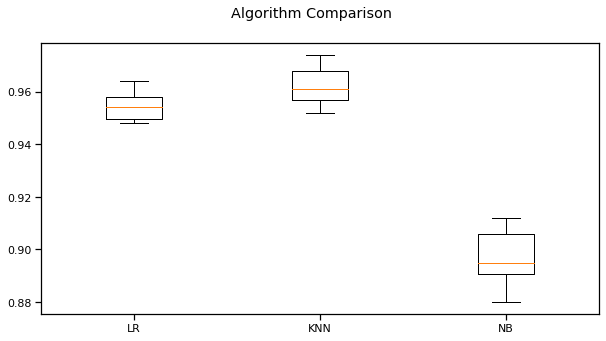

```python
models = []
models.append(('LR', LogisticRegression()))
models.append(('KNN', KNeighborsClassifier()))
models.append(('NB', GaussianNB()))
# evaluate each model in turn
results = []
names = []
scoring = 'accuracy'
for name, model in models:
    kfold = model_selection.KFold(n_splits=10, random_state=12345)
    cv_results = model_selection.cross_val_score(model, X, y, cv=kfold, scoring=scoring)
    results.append(cv_results)
    names.append(name)
    msg = "%s: %f (%f)" % (name, cv_results.mean(), cv_results.std())
    print(msg)



# boxplot algorithm comparison
fig = plt.figure(figsize=(10,5))
fig.suptitle('Algorithm Comparison')
ax = fig.add_subplot(111)
plt.boxplot(results)
ax.set_xticklabels(names)
plt.show()
```

### Summary :

- The aim of the Thera Bank is to convert there liability customers into loan customers.
- They want to set up a new marketing campaign; hence, they need information about the connection between the variables given in the data.
- Three classification algorithms were used in this study.
- From the above graph , it seems like 'KNN' algorithm have the highest accuracy and we can choose that as our final model